# 02 Text Embedding and Classification Tasks

# 4 Text Embedding

## 4.1 Introduction

In *aifedcuation*, a text embedding model is stored as an object of the class `TextEmbeddingModel`. This object contains all relevant information for transforming raw texts into a numeric representation that can be used for machine learning.

In *aifedcuation*, the transformation of raw texts into numbers is a separate step from downstream tasks such as classification. This is to reduce computational time on machines with low performance. By separating text embedding from other tasks, the text embedding has to be calculated only once and can be used for different tasks at the same time. Another advantage is that the training of the downstream tasks involves only the downstream tasks an not the parameters of the embedding model, making training less time-consuming, thus decreasing computational intensity. Finally, this approach allows the analysis of long documents by applying the same algorithm to different parts.

The text embedding model provides a unified interface: After creating the model with different methods, the handling of the model is always the same.

In the following we will show you how to use this object. We start with Topic Modeling.

## 4.2 Creating Text Embedding Models

### 4.2.1 Topic Modeling

For creating a new text embedding model based on Topic Modeling, you only need a basic text representation generated with the function `bow_pp_create_basic_text_rep()` (see section 2.2). Now you can create a new instance of a text embedding model by calling `TextEmbeddingModel$new()`.

```r
topic_modeling<-TextEmbeddingModel$new(
  model_name="topic_model_embedding",
  model_label="Text Embedding via Topic Modeling",
  model_version="0.0.1",
  model_language="english",
  method="lda",
  bow_basic_text_rep=basic_text_rep,
  bow_n_dim=12,
  bow_max_iter=500,
  bow_cr_criterion=1e-8,
  trace=TRUE
)
```

First you have to provide a name for your new model (`model_name`). This should be a unique but short name without any spaces. With `model_label` you can provide a label for your model with more freedom. It is important that you provide a version for your model in case you want to create an improved version in the future. With `model_language` you provide users the information for which language your model is designed. This is very important if you plan to share your model to a wider community.

With `method` you determine which approach should be used for your model. If you would like to use Topic Modeling, you have to set `method = "lda"`. the number of topics is set via `bow_n_dim`. In this example we would like to create a topic model with twelve topics. The number of topics also determines the dimensionality for our text embedding. Consequently, every text will be characterized by these twelve topics.

Please do not forget to pass your basic text representation to `bow_basic_text_rep`.

After the model is estimated, it is stored as `topic_modeling` in our example.

### 4.2.2 GlobalVectorClusters

The creation of a text embedding model based on GlobalVectorClusters is very similar to a model based on Topic Modeling. There are only two differences.

```r
global_vector_clusters_modeling<-TextEmbeddingModel$new(
  model_name="global_vector_clusters_embedding",
  model_label="Text Embedding via Clusters of GlobalVectors",
  model_version="0.0.1",
  model_language="english",
  method="glove_cluster",
  bow_basic_text_rep=basic_text_rep,
  bow_n_dim=96,
  bow_n_cluster=384,
  bow_max_iter=500,
  bow_max_iter_cluster=500,
  bow_cr_criterion=1e-8,
  trace=TRUE
)
```

First, you request a model based on GlobalVectorCluster by setting `method="glove_cluster"`. Second, you have to determine the dimensionality of the global vectors with `bow_n_dim` and the number of clusters by `bow_n_cluster`. When creating a new text embedding model, the global vector of each token is calculated based on the feature-co-occurrence-matrix (fcm) you provide with `basic_text_rep`. For very token, a vector is calculated with the length of `bow_n_dim`. Since these vectors are **word** embeddings and not **text** embeddings, an additional step is necessary to create text embeddings. In *aifedcuation* the word embeddings are used to group the words into clusters. The number of clusters is set with `bow_n_cluster`. Now, the text embedding is produced by counting the tokens of every cluster for every text.

The final model is stored as `global_vector_clusters_modeling`.

### 4.2.3 Transformers

Using a transformer for creating a text embedding model is similar to the other two approaches.

```r
bert_modeling<-TextEmbeddingModel$new(
  model_name="bert_embedding",
  model_label="Text Embedding via BERT",
  model_version="0.0.1",
  model_language="english",
  method = "bert",
  max_length = 512,
  chunks=4,
  overlap=30,
  aggregation="last",
  model_dir="my_own_transformer_trained"
  )
```

To request a model based on a transformer you must set `method` accordingly. Since we use a BERT model in our example, we have to set `method = "bert"`. Next, you have to provide the directory where your model is stored. In this example this would be `bert_model_dir_path="my_own_transformer_trained`. Of course you can use any other pre-trained model from Huggingface which addresses your needs.

Using a BERT model for text embedding is not a problem since your text does not provide more tokens than the transformer can process. This maximal value is set in the configuration of the transformer (see section 2.3). If the text produces more tokens the last tokens are ignored. In some instances you might want to analyze long texts. In these situations, reducing the text to the first tokens (e.g. only the first 512 tokens) could result in a problematic loss of information. To deal with these situations you can configure a text embedding model in *aifecuation* to split long texts into several chunks which are processed by the transformer. The maximal number of chunks is set with `chunks`. In our example above, the text embedding model would split a text consisting of 1024 tokens into two chunks with every chunk consisting of 512 tokens. For every chunk a text embedding is calculated. As a result, you receive a sequence of embeddings. The first embeddings characterizes the first part of the text and the second embedding characterizes the second part of the text (and so on). Thus, our example text embedding model is able to process texts with about 4*512=2048 tokens. This approach is inspired by the work by Pappagari et al. (2019).

Since transformers are able to account for the context, it may be useful to interconnect every chunk to bring context into the calculations. This can be done with `overlap` to determine how many tokens of the end of a prior chunk should be added to the next.In our example the last 30 tokens of the prior chunks are added at the beginning of the following chunk. This can help to add the correct context of the text sections into the analysis. Altogether, this example model can analyse a maximum of 512+(4-1)*(512-30)=1958 tokens of a text.

Finally, you have to decide from which hidden layer or layers the embeddings should be drawn (`aggregation="last"`). In their initial work, Devlin et al. (2019) used the hidden states of different layers for classification.

After deciding about the configuration, you can use your model.

## 4.3 Transforming Raw Texts into Embedded Texts

Although the mechanics within a text embedding model are different, the usage is always the same. To transform raw text into a numeric representation you only have to use the `embed` method of your model. To do this, you must provide the raw texts to `raw_text`. In addition, it is necessary that you provide a character vector containing the ID of every text. The IDs must be unique.

```r
topic_embeddings<-topic_modeling$embed(
  raw_text=example_data$text,
  doc_id=example_data$id,
  trace = TRUE)

cluster_embeddings<-global_vector_clusters_modeling$embed(
  raw_text=example_data$text,
  doc_id=example_data$id,
  trace = TRUE)

bert_embeddings<-bert_modeling$embed(
  raw_text=example_data$text,
  doc_id=example_data$id,
  trace = TRUE)
```

The method `embed`creates an object of class `EmbeddedText`. This is just a data.frame consisting the embedding of every text. Depending on the method, the data.frame has a different meaning:

- **Topic Modeling:** Regarding topic modeling, the rows represent the texts and the columns represent the percentage of every topic within a text.
- **GlobalVectorClusters:** Here, the rows represent the texts and the columns represent the absolute frequencies of tokens belonging to a semantic cluster.
- **Transformer - Bert:** With BERT, the rows represent the texts and the columns represents the contextualized text embedding or BERT’s understanding of the relevant text chunk.

Please note that in the case of transformer models, the embeddings of every chunks are interlinked.

With the embedded texts you now have the input to train a new classifier or to apply a pre-trained classifier for predicting categories/classes. In the next chapter we will show you how to use these classifiers. But before we start, we will show you how to save and load your model.

## 4.4 Saving and Loading Text Embedding Models

Saving a created text embedding model is very easy in aifeducation by using the function `save_ai_model`. This function provides a unique interface for all text embedding models. For saving your work you can pass your model to `model` and the directory where to save the model to `model_dir`. Please do only pass the path of a directory and not the path of a file to this function. Internally the function creates a new folder in the directory where all files belonging to a model are stored.

```r
save_ai_model(
  model=topic_modeling,
  model_dir="text_embedding_models",
  append_ID=FALSE)

save_ai_model(
  model=global_vector_clusters_modeling,
  model_dir="text_embedding_models",
  append_ID=FALSE)

save_ai_model(
  model=bert_modeling,
  model_dir="text_embedding_models",
  append_ID=FALSE)
```

As you can see all three text embedding models are saved within the same directory named “text_embedding_models”. Within this directory the function creates a unique folder for every model. The name of the folder is created by using the models’ names. Since the files are stored with a special structure please do **not** change the files manually.

If you change the argument `append_ID` to `append_ID=TRUE` the unique ID of the model is added to the directory. The ID is added automatically to ensure that every model has a unique name. This is important if you would like to share your work with other persons.

If you want to load your model, just call the function `load_ai_model` and you can continue using your model.

```r
topic_modeling<-load_ai_model(
  model_dir="text_embedding_models/topic_model_embedding")

global_vector_clusters_modeling<-load_ai_model(
  model_dir="text_embedding_models/global_vector_clusters_embedding")

bert_modeling<-load_ai_model(
  model_dir="text_embedding_models/bert_embedding")
```

> **Note:** In the documentation of the function you find an argument `ml_framework`. Please do *not* change the argument manually since this argument is controlled by the global configuration you have set at the beginning of a session (see section 2).

**Please note that you have to add the name of the model to the directory path.** In our example we have stored three models in the directory “text_embedding_models”. Each model is saved within its own folder. The folder’s name is created automatically with the help of the name of the model. Thus, for loading a model you must specify which model you want to load by adding the model’s name to the directory path as shown above.

Now you can use your text embedding model.

## 4.5 Sustainability

In the case the underlying model was trained with an active sustainability tracker (section 3.3) you can receive a table showing you the energy consumption, CO2 emissions, and hardware used during training by calling `bert_modeling$get_sustainability_data()`.

# 5 Using AI for Classification

## 5.1 Creating a New Classifier

In *aifedcuation*, classifiers are based on neural nets and stored in objects of the class `TextEmbeddingClassifierNeuralNet`. You can create a new classifier by calling `TextEmbeddingClassifierNeuralNet$new()`.

```r
example_targets<-as.factor(example_data$label)
names(example_targets)=example_data$id

classifier<-TextEmbeddingClassifierNeuralNet$new(
  name="movie_review_classifier",
  label="Classifier for Estimating a Postive or Negative Rating of Movie Reviews",
  text_embeddings=bert_embeddings,
  targets=example_targets,
  hidden=NULL,
  rec=c(256),
  self_attention_heads = 2,
  dropout=0.4,
  recurrent_dropout=0.4,
  l2_regularizer=0.01,
  optimizer="adam",
  act_fct="gelu",
  rec_act_fct="tanh")
```

Similar to the text embedding model you should provide a name (`name`) and a label (`label`) for your new classifier. With `text_embeddings` you have to provide an embedded text. We would like to recommend that you use the embedding you would like to use for training. We here continue our example and use the embedding produced by our BERT model.

`targets` takes the target data for the supervised learning. Please do not omit cases which have no category/class since they can be used with a special training technique we will show you later. It is very important that you provide the target data as factors. Otherwise an error will occur. It is also important that you name your factor. That is, the entries of the factor mus have names that correspond to the IDs of the corresponding texts. Without these names the method cannot match the input data (text embeddings) to the target data.

With the other parameters you decide about the structure of your classifier. Figure 4 illustrates this.

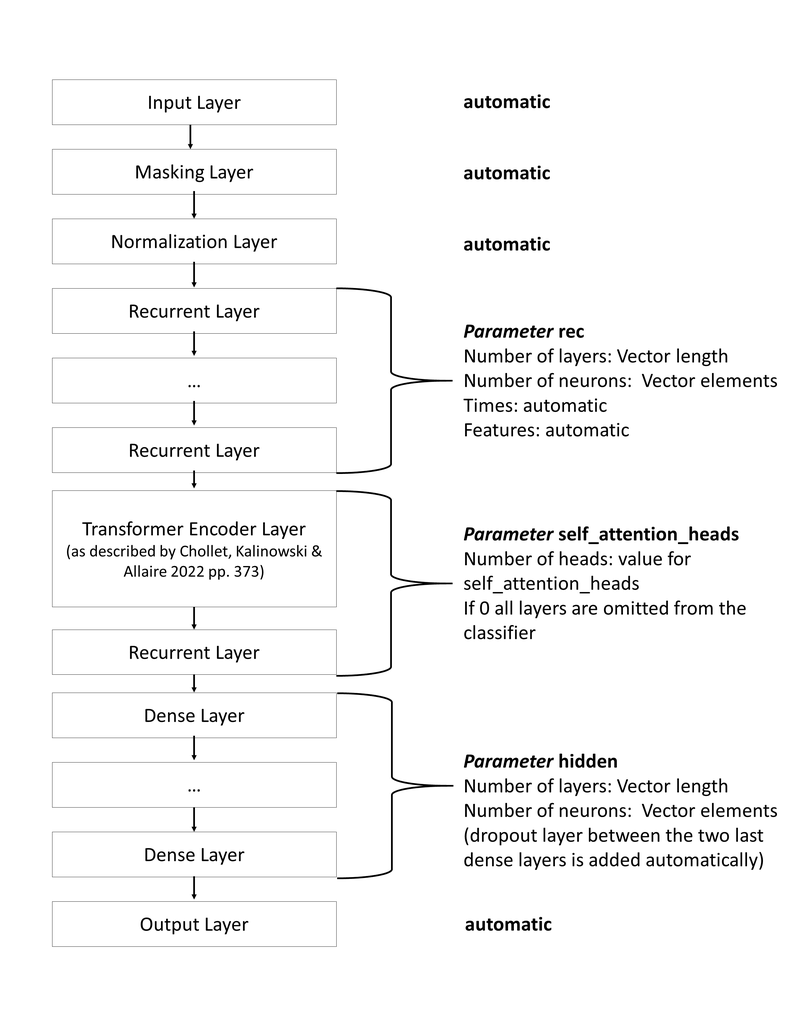

Figure 4: Overview of Possible Structure of a Classifier

`hidden` takes a vector of integers, determining the number of layers and the number of neurons. In our example, there are no dense layers. `rec` also takes a vector of integers determining the number and size of the Gated Recurrent Unit (gru). In this example, we use one layer with 256 neurons.

Since the classifiers in *aifeducation* use a standardized scheme for their creation, dense layers are used after the gru layers. If you want to omit gru layers or dense layers, set the corresponding argument to `NULL`.

If you use a text embedding model that processes more than one chunk we would like to recommend to use recurrent layers since they are able to use the sequential structure of your data. In all other cases you can rely on dense layers only.

If you use text embeddings with more than one chunk, it is a good idea to try self-attention layering in order to take the context of all chunks into account. To add a self-attention layer you must provide an integer greater 0 to `self_attention_heads`. This will not only add a self-attention layer but a transformer encoder as described by Chollet, Kalinowski, and Allaire (2022, pp. 373).

Masking, normalization, and the creation of the input layer as well as the output layer are done automatically.

After you have created a new classifier, you can begin training.

> **Note:** In the documentation of the function you find an argument `ml_framework`. Please do *not* change the argument manually since this argument is controlled by the global configuration you have set at the beginning of a session (see section 2).

> **Note:** Since the classifier is written with ‘keras’ using a classifier with ‘PyTorch’ requires at least ‘keras version 3’. In the case your system is not compatible with ‘keras version 3’ you can sill use the classifiers with ‘tensorflow’.

## 5.2 Training a Classifier

To start the training of your classifier, you have to call the `train` method. Similarly, for the creation of the classifier, you must provide the text embedding to `data_embeddings` and the categories/classes as target data to `data_targets`. Please remember that `data_targets` expects a **named** factor where the names correspond to the IDs of the corresponding text embeddings. Text embeddings and target data that cannot be matched are omitted from training.

To train a classifier, it is necessary that you provide a path to `dir_checkpoint`. This directory stores the best set of weights during each training epoch. After training, these weights are automatically used as final weights for the classifier.

For performance estimation, training splits the data into several chunks based on cross-fold validation. The number of folds is set with `data_n_test_samples`. In every case, one fold is not used for training and serves as a *test* sample. The remaining data is used to create a *training* and a *validation* sample. All performance values saved in the trained classifier refer to the test sample. This data has never been used during training and provides a more realistic estimation of a classifier`s performance.

```r
example_targets<-as.factor(example_data$label)
names(example_targets)=example_data$id

classifier$train(
   data_embeddings = bert_embeddings,
   data_targets = example_targets,
   data_n_test_samples=5,
   use_baseline=TRUE,
   bsl_val_size=0.33,
   use_bsc=TRUE,
   bsc_methods=c("dbsmote"),
   bsc_max_k=10,
   bsc_val_size=0.25,
   use_bpl=TRUE,
   bpl_max_steps=5,
   bpl_epochs_per_step=30,
   bpl_dynamic_inc=TRUE,
   bpl_balance=FALSE,
   bpl_max=1.00,
   bpl_anchor=1.00,
   bpl_min=0.00,
   bpl_weight_inc=0.00,
   bpl_weight_start=1.00,
   bpl_model_reset=TRUE,
   epochs=30,
   batch_size=8,
   sustain_track=TRUE,
   sustain_iso_code="DEU",
   sustain_region=NULL,
   sustain_interval=15,
   trace=TRUE,
   view_metrics=FALSE,
   keras_trace=0,
   n_cores=2,
   dir_checkpoint="training/classifier")
```

Since *aifedcuation* tries to address the special needs in educational and social science, some special training steps are integrated into this method.

- **Baseline:** If you are interested in training your classifier without applying any additional statistical techniques, you should set `use_baseline = TRUE`. In this case, the classifier is trained with the provided data as it is. Cases with missing values in target data are omitted. Even if you would like to apply further statistical adjustments, it makes sense to compute a baseline model for comparing the effect of the modified training process with unmodified training. By using `bsl_val_size` you can determine how much data should be used as training data and how much should be used as validation data.
- **Balanced Synthetic Cases:** In case of imbalanced data, it is recommended to set `use_bsc=TRUE`. Before training, a number of synthetic units is created via different techniques. Currently you can request *Basic Synthetic Minority Oversampling Technique*, *Density-Bases Synthetic Minority Oversampling Technique*, and *Adaptive Synthetic Sampling Approach for Imbalanced Learning*. The aim is to create new cases that fill the gap to the majority class. Multi-class problems are reduced to a two class problem (class under investigation vs. each other) for generating these units. You can even request several techniques at once. If the number of synthetic units and original minority units exceeds the number of cases of the majority class, a random sample is drawn. If the technique allows to set the number of neighbors during generation, `k = bsc_max_k` is used.
- **Balanced Pseudo-Labeling:** This technique is relevant if you have labeled target data and a large number of unlabeled target data. With the different parameter starting with “bpl_”, you can request different implementations of pseudo-labeling, for example based on the work by Lee (2013) or by Cascante-Bonilla et al. (2020). To turn on pseudo-labeling, you have to set `use_bpl=TRUE`.

To request pseudo-labeling based on Cascante-Bonilla et al. (2020), the following parameters have to be set:

- `bpl_max_steps = 5` (splits the unlabeled data into five chunks)
- `bpl_dynamic_inc = TRUE` (ensures that the number of used chunks increases at every step)
- `bpl_model_reset = TRUE` (re-initializes the model for every step)
- `bpl_epochs_per_step=30` (number of training epochs within each step)
- `bpl_balance=FALSE` (ensures that the cases with the highest certainty are added to training regardless of the absolute frequencies of the classes)
- `bpl_weight_inc=0.00` and `bpl_weight_start=1.00` (ensures that labeled and unlabeled data have the same weight during training)
- `bpl_max=1.00`, `bpl_anchor=1.00`, and `bpl_min=0.00` (ensures that all unlabeled data is considered for training and that cases with the highest certainty are used for training.)

To request the original pseudo-labeling proposed by Lee (2013), you have to set the following parameters:

- `bpl_max_steps=30` (steps must be treated as epochs)
- `bpl_dynamic_inc=FALSE` (ensures that all pseudo-labeled cases are used)
- `bpl_model_reset=FALSE` (the model is not allowed to be re-initialized)
- `bpl_epochs_per_step=1` (steps are treated as epochs so this must be one)
- `bpl_balance=FALSE` (ensures that all cases are added regardless of the absolute frequencies of the classes)
- `bpl_weight_inc=0.02` and `bpl_weight_start=0.00` (gives the pseudo labeled data an increasing weight with every step)
- `bpl_max=1.00`, `bpl_anchor=1.00`, and `bpl_min=0.00` (ensures that all pseudo labeled cases are used for training. `bpl_anchor` does not affect the calculations)

Please note that while Lee (2013) suggests to recalculate the pseudo-labels of the unlabeled data after every weight actualization, in *aifeducation*, the pseudo-labels are recalculated after every epoch.

`bpl_max=1.00`, `bpl_anchor=1.00`, and `bpl_min=0.00` are used to describe the certainty of a prediction. 0 refers to random guessing while 1 refers to perfect certainty. `bpl_anchor` is used as a reference value. The distance to `bpl_anchor` is calculated for every case. Then, they are sorted with an increasing distance from `bpl_anchor`. The resulting order of cases is relevant if you set `bpl_dynamic_inc=TRUE` or `bpl_balance=TRUE`.

Figure 5 illustrates the training loop for the cases that all three options are set to `TRUE`.

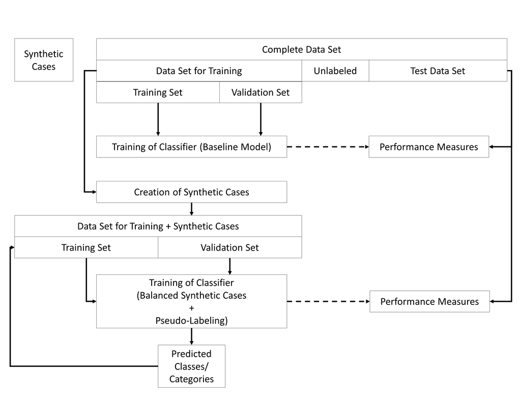

Figure 5: Overview of the Steps to Perform a Classification

The example above applies the algorithm proposed by Cascante-Bonilla et al. (2020). After training the classifier on the labeled data, the unlabeled data is introduced into the training. The classifier predicts the potential labels of the unlabeled data and adds 20% of the cases with the highest certainty for their pseudo-labels to the training. The classifier is re-initialized and trained again. After training, the classifier predicts the potential labels of *all* originally unlabeled data and adds 40% of the pseudo-labeled data to the training data. The model is again re-initialized and trained again until all unlabeled data is used for training.

Since training a neural net is energy consuming *aifeducation* allows you to estimate its ecological impact with help of the python library `codecarbon`. Thus, `sustain_track` is set to `TRUE` by default. If you use the sustainability tracker you must provide the alpha-3 code for the country where your computer is located (e.g., “CAN”=“Canada”, “Deu”=“Germany”). A list with the codes can be found on [wikipedia](https://en.wikipedia.org/wiki/ISO_3166-1_alpha-3). The reason is that different countries use different sources and techniques for generating their energy resulting in a specific impact on CO2 emissions. For USA and Canada you can additionally specify a region by setting `sustain_region`. Please refer to the documentation of codecarbon for more information.

Finally, `trace`, `view_metrics`, and `keras_trace` allow you to control how much information about the training progress is printed to the console. Please note that training the classifier can take some time.

Please note that after performance estimation, the final training of the classifier makes use of all data available. That is, the test sample is left empty.

## 5.3 Evaluating Classifier’s Performance

After finishing training, you can evaluate the performance of the classifier. For every fold, the classifier is applied to the test sample and the results are compared to the true categories/classes. Since the test sample is never part of the training, all performance measures provide a more realistic idea of the classifier`s performance.

To support researchers in judging the quality of the predictions, *aifeducation* utilizes several measures and concepts from content analysis. These are

- Iota Concept of the Second Generation (Berding & Pargmann 2022)
- Krippendorff’s Alpha (Krippendorff 2019)
- Percentage Agreement
- Gwet’s AC1/AC2 (Gwet 2014)
- Kendall’s coefficient of concordance W
- Cohen’s Kappa with equal weights
- Fleiss’ Kappa for multiple raters with exact estimation
- Light’s Kappa for multiple raters

You can access the concrete values by accessing the field `reliability` which stores all relevant information. In this list you will find the reliability values for every fold and for every requested training configuration. In addition, the reliability of every step within balanced pseudo-labeling is reported.

The central estimates for the reliability values can be found via `reliability$test_metric_mean`. In our example this would be:

```r
classifier$reliability$test_metric_mean
```

```r
test_metric_mean
```

```
#>          iota_index  min_iota2 avg_iota2 max_iota2 min_alpha avg_alpha
#> Baseline  0.6320000 0.10294118 0.3877251 0.6725090     0.136     0.549
#> BSC       0.4346667 0.06895416 0.2676750 0.4663959     0.072     0.512
#> BPL       0.6293333 0.51019563 0.6401731 0.7701506     0.580     0.756
#> Final     0.6293333 0.51019563 0.6401731 0.7701506     0.580     0.756
#>          max_alpha static_iota_index dynamic_iota_index kalpha_nominal
#> Baseline     0.962         0.5455732          0.5281005    -0.04487101
#> BSC          0.952         0.3785559          0.3744595    -0.25488654
#> BPL          0.932         0.3846018          0.5242565     0.54678492
#> Final        0.932         0.3846018          0.5242565     0.54678492
#>          kalpha_ordinal   kendall     kappa2 kappa_fleiss kappa_light
#> Baseline    -0.04487101 0.5531797 0.10142922   0.10142922  0.10142922
#> BSC         -0.25488654 0.5199922 0.02869454   0.02869454  0.02869454
#> BPL          0.54678492 0.7827658 0.55104690   0.55104690  0.55104690
#> Final        0.54678492 0.7827658 0.55104690   0.55104690  0.55104690
#>          percentage_agreement  gwet_ac
#> Baseline            0.6866667 0.543828
#> BSC                 0.4920000 0.106742
#> BPL                 0.8146667 0.686684
#> Final               0.8146667 0.686684
```

Finally, you can plot a coding stream scheme showing how the cases of different classes are labeled. Here we use the package *iotarelr*.

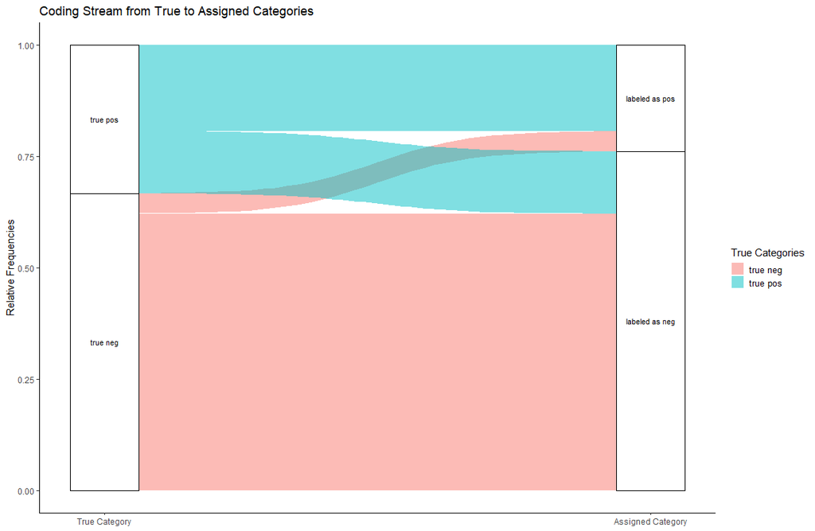

Figure 6: Coding Stream of the Classifier

```r
library(iotarelr)
iotarelr::plot_iota2_alluvial(test_classifier$reliability$iota_object_end_free)
```

Here you can see that a small number of negative reviews is treated as a good review while a larger number of positive reviews is treated as a bad review. Thus, the data for the major class (negative reviews) is more reliable and valid as the the data for the minor class (positive reviews).

Evaluating the performance of a classifier is a complex task and and beyond the scope of this vignette. Instead, we would like to refer to the cited literature of content analysis and machine learning if you would like to dive deeper into this topic.

## 5.4 Sustainability

In the case the classifier was trained with an active sustainability tracker you can receive information on sustainability by calling `classifier$get_sustainability_data()`.

```r
sustainability_data
```

```
#> $sustainability_tracked
#> [1] TRUE
#>
#> $date
#> [1] "Thu Oct  5 11:20:53 2023"
#>
#> $sustainability_data
#> $sustainability_data$duration_sec
#> [1] 7286.503
#>
#> $sustainability_data$co2eq_kg
#> [1] 0.05621506
#>
#> $sustainability_data$cpu_energy_kwh
#> [1] 0.08602103
#>
#> $sustainability_data$gpu_energy_kwh
#> [1] 0.05598303
#>
#> $sustainability_data$ram_energy_kwh
#> [1] 0.01180879
#>
#> $sustainability_data$total_energy_kwh
#> [1] 0.1538128
#>
#>
#> $technical
#> $technical$tracker
#> [1] "codecarbon"
#>
#> $technical$py_package_version
#> [1] "2.3.1"
#>
#> $technical$cpu_count
#> [1] 12
#>
#> $technical$cpu_model
#> [1] "12th Gen Intel(R) Core(TM) i5-12400F"
#>
#> $technical$gpu_count
#> [1] 1
#>
#> $technical$gpu_model
#> [1] "1 x NVIDIA GeForce RTX 4070"
#>
#> $technical$ram_total_size
#> [1] 15.84258
#>
#>
#> $region
#> $region$country_name
#> [1] "Germany"
#>
#> $region$country_iso_code
#> [1] "DEU"
#>
#> $region$region
#> [1] NA
```

## 5.5 Saving and Loading a Classifier

If you have created a classifier, saving and loading is very easy. The process for saving a model is similar to the process for text embedding models. You only have to pass the model and a directory path to the function `save_ai_model`.

```r
save_ai_model(
  model=classifier,
  model_dir="classifiers",
  save_format = "keras",
  append_ID=FALSE)
```

In contrast to text embedding models you can specify the additional argument `save_format` allowing you to choose between `save_format = "keras"`, `save_format = "tf"` and `save_format = "h5"`. We recommend to chose `save_format = "keras"` since this is allows to use the classifier with both ‘PyTorch’ and ‘tensorflow’.

If you would like to load a model you can call the function `load_ai_model`.

```r
classifier<-load_ai_model(
  model_dir="classifiers/movie_review_classifier")
```

> **Note:** In the documentation of the function you find an argument `ml_framework`. Please do *not* change the argument manually since this argument is controlled by the global configuration you have set at the beginning of a session (see section 2).

> **Note:** Since the classifier is written with ‘keras’ using a classifier with ‘PyTorch’ requires at least ‘keras version 3’. In the case your system is not compatible with ‘keras version 3’ you can sill use the classifiers with ‘tensorflow’.

## 5.6 Predicting New Data

If you would like to apply your classifier to new data, two steps are necessary. You must first transform the raw text into a numerical expression by using *exactly* the same text embedding model that was used for training your classifier. In the case of our example classifier we use our BERT model.

```r
# If our mode is not loaded
bert_modeling<-load_ai_model(
  model_dir="text_embedding_models/bert_embedding")

# Create a numerical representation of the text
text_embeddings<-bert_modeling$embed(
  raw_text = textual_data$texts,
  doc_id = textual_data$doc_id,
  batch_size=8,
  trace=TRUE)
```

To transform raw texts into a numeric representation Just pass the raw texts and the IDs of every text to the method `embed` of the loaded model. This is very easy if you used the package readtext to read raw text from disk, since the object resulting from `readtext` always stores the texts in the column “texts” and the IDs in the column “doc_id”.

Depending on your machine, embedding raw texts may take some time. In case you use a machine with a graphic device, it is possible that an “out of memory” error occurs. In this case reduce the batch size. If the error still occurs, restart the *R* session, switch to cpu-only mode *directly* after loading the libraries with `aifeducation::set_config_cpu_only()` and request the embedding again.

In the example above, the text embeddings are stored in `text_embedding`. Since embedding texts may take some time, it is a good idea to save the embeddings for future analysis (use the `save` function of *R*). This allows you to load the embedding without the need to apply the text embedding model on the same raw texts again.

The resulting object can then be passed to the method `predict` of our classifier and you will get the predictions together with an estimate of certainty for each class/category.

```r
# If your classifier is not loaded
classifier<-load_ai_model(
  model_dir="classifiers/movie_review_classifier")

# Predict the classes of new texts
predicted_categories<-classifier$predict(
  newdata = text_embeddings,
  batch_size=8,
  verbose=0)
```

After the classifier finishes the prediction, the estimated categories/classes are stored as `predicted_categories`. This object is a `data.frame` containing texts’ IDs in the rows and the probabilities of the different categories/classes in the columns. The last column with the name `expected_category` represents the category which is assigned to a text due the highest probability.

The estimates can be used in further analysis with common methods of the educational and social sciences such as correlation analysis, regression analysis, structural equation modeling, latent class analysis or analysis of variance.

# References

Beltagy, I., Peters, M. E., & Cohan, A. (2020). Longformer: The Long-Document Transformer. https://doi.org/10.48550/arXiv.2004.05150

Berding, F., & Pargmann, J. (2022). Iota Reliability Concept of the Second Generation. Berlin: Logos. https://doi.org/10.30819/5581

Berding, F., Riebenbauer, E., Stütz, S., Jahncke, H., Slopinski, A., & Rebmann, K. (2022). Performance and Configuration of Artificial Intelligence in Educational Settings.: Introducing a New Reliability Concept Based on Content Analysis. Frontiers in Education, 1–21. https://doi.org/10.3389/feduc.2022.818365

Cascante-Bonilla, P., Tan, F., Qi, Y. & Ordonez, V. (2020). Curriculum Labeling: Revisiting Pseudo-Labeling for Semi-Supervised Learning. https://doi.org/10.48550/arXiv.2001.06001

Campesato, O. (2021). Natural Language Processing Fundamentals for Developers. Mercury Learning & Information. https://ebookcentral.proquest.com/lib/kxp/detail.action?docID=6647713

Chollet, F., Kalinowski, T., & Allaire, J. J. (2022). Deep learning with R (Second edition). Manning Publications Co. https://learning.oreilly.com/library/view/-/9781633439849/?ar

Devlin, J., Chang, M.‑W., Lee, K., & Toutanova, K. (2019). BERT: Pre-training of Deep Bidirectional Transformers for Language Understanding. In J. Burstein, C. Doran, & T. Solorio (Eds.), Proceedings of the 2019 Conference of the North (pp. 4171–4186). Association for Computational Linguistics. https://doi.org/10.18653/v1/N19-1423

Gwet, K. L. (2014). Handbook of inter-rater reliability: The definitive guide to measuring the extent of agreement among raters (Fourth edition). Gaithersburg: STATAXIS.

Krippendorff, K. (2019). Content Analysis: An Introduction to Its Methodology (4th ed.). Los Angeles: SAGE.

Lane, H., Howard, C., & Hapke, H. M. (2019). Natural language processing in action: Understanding, analyzing, and generating text with Python. Shelter Island: Manning.

Larusson, J. A., & White, B. (Eds.). (2014). Learning Analytics: From Research to Practice. New York: Springer. https://doi.org/10.1007/978-1-4614-3305-7

Lee, D.‑H. (2013). Pseudo-Label: The Simple and Efficient Semi-Supervised Learning Method for Deep Neural Networks. CML 2013 Workshop: Challenges in Representation Learning.

Papilloud, C., & Hinneburg, A. (2018). Qualitative Textanalyse mit Topic-Modellen: Eine Einführung für Sozialwissenschaftler. Wiesbaden: Springer. https://doi.org/10.1007/978-3-658-21980-2

Pappagari, R., Zelasko, P., Villalba, J., Carmiel, Y., & Dehak, N. (2019). Hierarchical Transformers for Long Document Classification. In 2019 IEEE Automatic Speech Recognition and Understanding Workshop (ASRU) (pp. 838–844). IEEE. https://doi.org/10.1109/ASRU46091.2019.9003958

Pennington, J., Socher, R., & Manning, C. D. (2014). GloVe: Global Vectors for Word Representation. Proceedings of the 2014 Conference on Empirical Methods in Natural Language Processing. https://aclanthology.org/D14-1162.pdf

Schreier, M. (2012). Qualitative Content Analysis in Practice. Los Angeles: SAGE.

Tunstall, L., Werra, L. von, Wolf, T., & Géron, A. (2022). Natural language processing with transformers: Building language applications with hugging face (Revised edition). Heidelberg: O’Reilly.

Vaswani, A., Shazeer, N., Parmar, N., Uszkoreit, J., Jones, L., Gomez, A. N., Kaiser, L., & Polosukhin, I. (2017). Attention Is All You Need. https://doi.org/10.48550/arXiv.1706.03762

Wu, Y., Schuster, M., Chen, Z., Le, Q. V., Norouzi, M., Macherey, W., Krikun, M., Cao, Y., Gao, Q., Macherey, K., Klingner, J., Shah, A., Johnson, M., Liu, X., Kaiser, Ł., Gouws, S., Kato, Y., Kudo, T., Kazawa, H., . . . Dean, J. (2016). Google’s Neural Machine Translation System: Bridging the Gap between Human and Machine Translation. https://doi.org/10.48550/arXiv.1609.08144